# IS 4487 Assignment 9: Customer Segmentation with Clustering

In this assignment, you will:

- Apply unsupervised learning to explore patterns in hotel booking behavior
- Use K-Means and Gaussian Mixture Models (GMM) for customer segmentation
- Evaluate model quality with metrics like Silhouette Score and Davies-Bouldin Index
- Connect clustering to actionable business insights

## Why This Matters

Businesses like hotels and travel platforms (e.g., Airbnb or Expedia) rely on customer segmentation to tailor promotions, pricing strategies, and service levels. Unlike supervised models, clustering helps uncover patterns when no labels exist—an ideal tool when entering new markets or analyzing unstructured customer behavior.

## Dataset Description: Hotel Bookings

This dataset contains booking information for two types of hotels: a **city hotel** and a **resort hotel**. Each record corresponds to a single booking and includes various details about the reservation, customer demographics, booking source, and whether the booking was canceled.

**Source**: [GitHub - TidyTuesday: Hotel Bookings](https://github.com/rfordatascience/tidytuesday/blob/master/data/2020/2020-02-11/readme.md)

### Key Use Cases

- Understand customer booking behavior
- Explore factors related to cancellations
- Segment guests based on booking characteristics
- Compare city vs. resort hotel performance

### Data Dictionary

| Variable | Type | Description |
| --- | --- | --- |
| `hotel` | character | Hotel type: City or Resort |
| `is_canceled` | integer | 1 = Canceled, 0 = Not Canceled |
| `lead_time` | integer | Days between booking and arrival |
| `arrival_date_year` | integer | Year of arrival |
| `arrival_date_month` | character | Month of arrival |
| `stays_in_weekend_nights` | integer | Nights stayed on weekends |
| `stays_in_week_nights` | integer | Nights stayed on weekdays |
| `adults` | integer | Number of adults |
| `children` | integer | Number of children |
| `babies` | integer | Number of babies |
| `meal` | character | Type of meal booked |
| `country` | character | Country code of origin |
| `market_segment` | character | Booking source (e.g., Direct, Online TA) |
| `distribution_channel` | character | Booking channel used |
| `is_repeated_guest` | integer | 1 = Repeated guest, 0 = New guest |
| `previous_cancellations` | integer | Past booking cancellations |
| `previous_bookings_not_canceled` | integer | Past bookings not canceled |
| `reserved_room_type` | character | Initially reserved room type |
| `assigned_room_type` | character | Room type assigned at check-in |
| `booking_changes` | integer | Number of booking modifications |
| `deposit_type` | character | Deposit type (No Deposit, Non-Refund, etc.) |
| `agent` | character | Agent ID who made the booking |
| `company` | character | Company ID (if booking through company) |
| `days_in_waiting_list` | integer | Days on the waiting list |
| `customer_type` | character | Booking type: Contract, Transient, etc. |
| `adr` | float | Average Daily Rate (price per night) |
| `required_car_parking_spaces` | integer | Requested parking spots |
| `total_of_special_requests` | integer | Number of special requests made |
| `reservation_status` | character | Final status (Canceled, No-Show, Check-Out) |
| `reservation_status_date` | date | Date of the last status update |

This dataset is ideal for classification, segmentation, and trend analysis exercises.

## 1. Setup and Load Data

### Business framing:

### Do the following:

Before we can cluster or segment anything, we need clean, accessible data in a usable format.

- Import the necessary Python libraries
- Import data from the hotels dataset into a dataframe (in GitHub go to the DataSets folder and look for `hotels.csv`)
- Display the first few rows
- Show summary statistics for the dataframe

```python
# Add code here 🔧
# 1. Import libraries
import pandas as pd
import numpy as np
import seaborn as sns
import matplotlib.pyplot as plt

from sklearn.preprocessing import StandardScaler
from sklearn.cluster import KMeans

# 2. Import hotels dataset
url = 'https://raw.githubusercontent.com/Stan-Pugsley/is_4487_base/main/DataSets/hotels.csv'

hotels = pd.read_csv(url)

# 3. Display first few rows
hotels.head()

# 4. Show summary statistics
hotels.describe()
```

|  | is_canceled | lead_time | arrival_date_year | arrival_date_week_number | arrival_date_day_of_month | stays_in_weekend_nights | stays_in_week_nights | adults | children | babies | is_repeated_guest | previous_cancellations | previous_bookings_not_canceled | booking_changes | agent | company | days_in_waiting_list | adr | required_car_parking_spaces | total_of_special_requests |
| --- | --- | --- | --- | --- | --- | --- | --- | --- | --- | --- | --- | --- | --- | --- | --- | --- | --- | --- | --- | --- |
| count | 9404.000000 | 9404.000000 | 9404.000000 | 9404.000000 | 9404.000000 | 9404.000000 | 9404.000000 | 9404.000000 | 9404.000000 | 9404.000000 | 9404.000000 | 9404.000000 | 9404.000000 | 9404.000000 | 7069.000000 | 1011.000000 | 9404.000000 | 9404.000000 | 9404.000000 | 9404.000000 |
| mean | 0.248299 | 79.326244 | 2015.156104 | 37.026584 | 15.515313 | 1.155040 | 3.078690 | 1.864738 | 0.095279 | 0.015419 | 0.077839 | 0.419715 | 0.290196 | 0.238622 | 200.990946 | 219.550940 | 1.019034 | 86.843614 | 0.144938 | 0.613143 |
| std | 0.432049 | 87.584146 | 0.443661 | 11.083421 | 9.025545 | 1.124304 | 2.379227 | 1.198565 | 0.393858 | 0.125781 | 0.267933 | 2.726546 | 1.352679 | 0.630041 | 80.330753 | 104.296474 | 10.137928 | 53.759940 | 0.353264 | 0.835930 |
| min | 0.000000 | 0.000000 | 2015.000000 | 1.000000 | 1.000000 | 0.000000 | 0.000000 | 0.000000 | 0.000000 | 0.000000 | 0.000000 | 0.000000 | 0.000000 | 0.000000 | 1.000000 | 9.000000 | 0.000000 | -6.380000 | 0.000000 | 0.000000 |
| 25% | 0.000000 | 8.000000 | 2015.000000 | 31.000000 | 7.000000 | 0.000000 | 1.000000 | 2.000000 | 0.000000 | 0.000000 | 0.000000 | 0.000000 | 0.000000 | 0.000000 | 156.000000 | 135.000000 | 0.000000 | 45.000000 | 0.000000 | 0.000000 |
| 50% | 0.000000 | 48.000000 | 2015.000000 | 38.000000 | 16.000000 | 1.000000 | 3.000000 | 2.000000 | 0.000000 | 0.000000 | 0.000000 | 0.000000 | 0.000000 | 0.000000 | 240.000000 | 223.000000 | 0.000000 | 71.550000 | 0.000000 | 0.000000 |
| 75% | 0.000000 | 118.000000 | 2015.000000 | 45.000000 | 23.000000 | 2.000000 | 5.000000 | 2.000000 | 0.000000 | 0.000000 | 0.000000 | 0.000000 | 0.000000 | 0.000000 | 241.000000 | 286.000000 | 0.000000 | 120.600000 | 0.000000 | 1.000000 |
| max | 1.000000 | 737.000000 | 2017.000000 | 53.000000 | 31.000000 | 13.000000 | 33.000000 | 55.000000 | 10.000000 | 2.000000 | 1.000000 | 26.000000 | 26.000000 | 17.000000 | 468.000000 | 511.000000 | 122.000000 | 508.000000 | 2.000000 | 5.000000 |

### Reflection:

1. What stands out in the initial preview? Any columns or rows that seem unusual?

### ✍️ Your Response: 🔧

1. The "Count" column is bizarre. There's a lot of 9404.000000s.

## 2. Select and Prepare Features

### Business framing:

A hotel might want to group guests based on how long they stay, how far in advance they book, or how likely they are to make special requests. You need to pick variables that represent meaningful guest behavior.

### Do the following:

- 2.1 Choose 3–5 numeric features related to customer behavior
- 2.2 Perform basic data preparation - remove outliers, remove duplicates, correct any datatypes that need adjustment
- 2.3 Drop missing values if needed
- 2.4 Standardize using `StandardScaler` for any large values (over 100)

```python
# Add code here 🔧
# 1. Remove duplicates
hotels = hotels.drop_duplicates()

# 2. Create total nights
hotels['total_nights'] = (hotels['stays_in_weekend_nights'] + hotels['stays_in_week_nights'])

# 3. Remove outliers
for col in ['lead_time', 'total_nights']:
    Q1 = hotels[col].quantile(0.25)
    Q3 = hotels[col].quantile(0.75)
    IQR = Q3 - Q1

    lower = Q1 - 1.5 * IQR
    upper = Q3 + 1.5 * IQR

    hotels = hotels[(hotels[col] >= lower) & (hotels[col] <= upper)]

# 4. Select five features
features = hotels[['lead_time', 'total_nights','booking_changes', 'previous_cancellations','total_of_special_requests']]

# 5. Drop missing values
features = features.dropna()

# 6. Standardize features
scaler = StandardScaler()
scaled_features = scaler.fit_transform(features)

scaled_df = pd.DataFrame(scaled_features,columns=features.columns,index=features.index)

# Preview standardized data
scaled_df.head()
```

|  | lead_time | total_nights | booking_changes | previous_cancellations | total_of_special_requests |
| --- | --- | --- | --- | --- | --- |
| 2 | -0.802657 | -1.028399 | -0.408149 | -0.105341 | -0.818351 |
| 3 | -0.694782 | -1.028399 | -0.408149 | -0.105341 | -0.818351 |
| 4 | -0.676802 | -0.698908 | -0.408149 | -0.105341 | 0.349617 |
| 6 | -0.928512 | -0.698908 | -0.408149 | -0.105341 | -0.818351 |
| 7 | -0.766699 | -0.698908 | -0.408149 | -0.105341 | 0.349617 |

### Reflection:

1. What features did you select and why?
2. What kinds of patterns or segments do you expect to find?

### ✍️ Your Response: 🔧

1. Features: 'lead_time', 'total_nights','booking_changes', 'previous_cancellations','total_of_special_requests'. I chose these features because a majority of them had the same number under "Count".
2. I think I'll patterns in guests who book in advance versus last minute and guests who make modify their reservations.

## 3. Apply K-Means Clustering

### Business framing:

Let’s say you’re working with the hotel’s marketing manager. She wants to group guests into a few clear types to target email campaigns. K-Means is a fast, simple way to try this.

### Do the following:

- Fit a `KMeans` model with your selected features
- Choose a value of `k` (e.g. 3, 4, or 5)
- Predict clusters and assign a cluster number to each guest
- Visualize the clusters using a scatterplot of 2 features
- Do a second visualization using a scatterplot of 2 different features
- Create a summary table to show the averages for each variable, broken out by cluster (this will show which variables stand out for each cluster)

Much of this assignment has already been covered in the lab. Please be sure to complete the lab before the assignment.

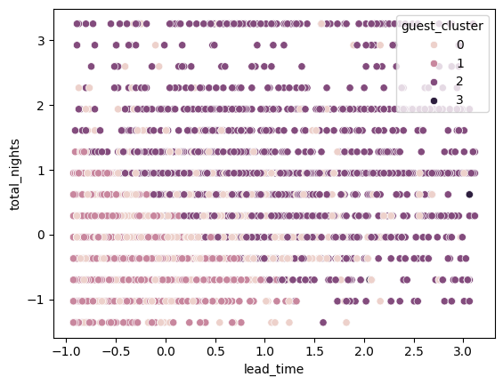

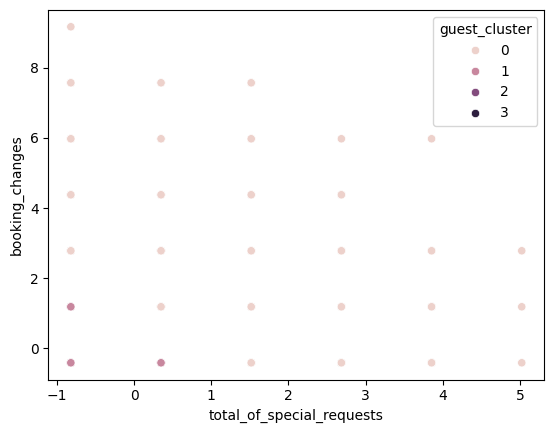

| guest_cluster | lead_time | total_nights | booking_changes | previous_cancellations | total_of_special_requests |
| --- | --- | --- | --- | --- | --- |
| 0 | 47.104950 | 4.069967 | 0.724752 | 0.054785 | 1.852805 |
| 1 | 17.012898 | 2.259960 | 0.125537 | 0.041273 | 0.303239 |
| 2 | 108.475659 | 7.055382 | 0.142028 | 0.055828 | 0.541313 |
| 3 | 203.333333 | 4.666667 | 0.000000 | 24.666667 | 0.000000 |

```python
# Add code here 🔧
# 1. Apply KMeans with 4 clusters
kmeans = KMeans(n_clusters=4, random_state=1)

scaled_df['guest_cluster'] = kmeans.fit_predict(scaled_df)

# 2. Count guests in each cluster
scaled_df['guest_cluster'].value_counts()

# 3. First scatterplot
sns.scatterplot(data=scaled_df, x='lead_time', y='total_nights', hue='guest_cluster')
plt.show()

# 4. Second scatterplot
sns.scatterplot(data=scaled_df, x='total_of_special_requests', y='booking_changes',hue='guest_cluster')
plt.show()

# 5. Cluster summary table
cluster_data = features.copy()
cluster_data['guest_cluster'] = scaled_df['guest_cluster']

cluster_summary = cluster_data.groupby('guest_cluster').mean()

cluster_summary
```

### Reflection:

1. What `k` value did you choose, and how did you decide?
2. For each cluster answer the following - what types of customers seem to show up in the cluster? which variables are most prominent or important for that cluster?

## 4. Apply Gaussian Mixture Model (GMM)

### Business framing:

Not all guests fit neatly into one cluster. GMM lets us capture uncertainty — useful if customers behave similarly across groups.

### Do the following:

- Fit a GMM with the same number of clusters you chose in Part 3
- Predict soft clusters (remember that soft clustering deals with probabilities, not labels)
- Visualize the clusters using a scatterplot of 2 features
- Do a second visualization using a scatterplot of 2 different features
- Create a summary table to show the averages for each variable, broken out by cluster (this will show which variables stand out for each cluster)

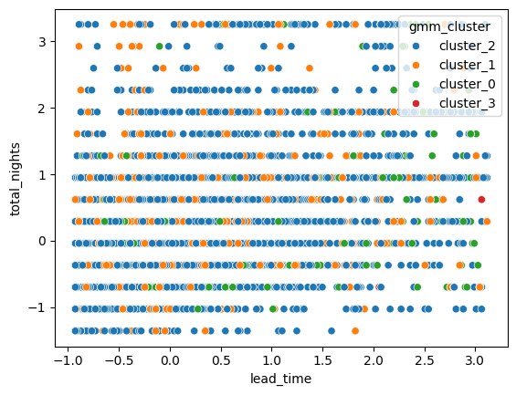

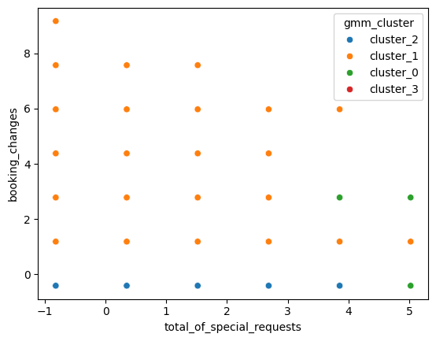

| gmm_cluster | lead_time | total_nights | booking_changes | previous_cancellations | total_of_special_requests |
| --- | --- | --- | --- | --- | --- |
| cluster_0 | 83.358730 | 4.190476 | 0.234921 | 1.117460 | 0.831746 |
| cluster_1 | 49.915319 | 4.569669 | 1.370285 | 0.000000 | 0.782910 |
| cluster_2 | 50.186712 | 4.013502 | 0.000000 | 0.000000 | 0.674720 |
| cluster_3 | 203.333333 | 4.666667 | 0.000000 | 24.666667 | 0.000000 |

```python
# Add your code here
X = scaled_df[features.columns]
from sklearn.mixture import GaussianMixture

gmm = GaussianMixture(n_components=4, random_state=1)
gmm.fit(X)

probabilities = gmm.predict_proba(X)
probabilities_df = pd.DataFrame(probabilities, columns=['cluster_0', 'cluster_1', 'cluster_2', 'cluster_3'],index=X.index)
probabilities_df.head()
gmm_cluster = probabilities_df.idxmax(axis=1)
gmm_data = scaled_df.copy()
gmm_data['gmm_cluster'] = gmm_cluster
sns.scatterplot(data=gmm_data, x='lead_time', y='total_nights', hue='gmm_cluster')
plt.show()
sns.scatterplot(data=gmm_data, x='total_of_special_requests', y='booking_changes', hue='gmm_cluster')
plt.show()
gmm_summary_data = features.copy()
gmm_summary_data['gmm_cluster'] = gmm_cluster

gmm_summary = gmm_summary_data.groupby('gmm_cluster').mean()

gmm_summary
```

### Reflection:

1. How did the GMM results compare to KMeans?
2. What business questions might GMM help answer better?

### ✍️ Your Response: 🔧

1. The range for the lead_times isn't as large, and the total_nights are for each cluster are more similar between 4-5 days.
2. GMM may be better at helping the hotel personalizing and targeting different customers especially those who cancel more frequently to encourage them to stay.

## 5. Evaluate Your Models

### Business framing:

In business, models should be both useful and reliable. You’ll compare model quality using standard evaluation metrics.

### Do the following:

- 5.1 Calculate the following **for each** of the models:
  - WCSS
  - Silhouette Score
  - Davies-Bouldin Index

  **NOTE:** This step may take up to 5 minutes. It is a lot of computation time. Please be patient. Or you can limit the scores to using a random sample of 10K rows.

**Remember**:

- Lower WCSS = tighter, better-defined clusters
- Silhouette score ranges from -1 to 1. Higher values = better clustering
- Lower Davies-Boulding Index = better clustering

```python
# Add code here 🔧
from sklearn.metrics import silhouette_score, davies_bouldin_score
# K-Means predictions
kmeans_labels = kmeans.predict(X)

# Calculate metrics
kmeans_wcss = kmeans.inertia_
kmeans_silhouette = silhouette_score(X, kmeans_labels)
kmeans_db = davies_bouldin_score(X, kmeans_labels)
# GMM predictions (most likely cluster)
gmm_labels = gmm.predict(X)

# Calculate metrics
gmm_wcss = sum(((X.iloc[i].values - gmm.means_[gmm_labels[i]]) ** 2).sum() for i in range(len(X)))
gmm_silhouette = silhouette_score(X, gmm_labels)
gmm_db = davies_bouldin_score(X, gmm_labels)

# GMM predictions (most likely cluster)
gmm_labels = gmm.predict(X)

# Calculate metrics
gmm_wcss = sum(((X.iloc[i].values - gmm.means_[gmm_labels[i]]) ** 2).sum() for i in range(len(X)))

gmm_silhouette = silhouette_score(X, gmm_labels)
gmm_db = davies_bouldin_score(X, gmm_labels)

results = pd.DataFrame({
    'Model': ['K-Means', 'GMM'],
    'WCSS': [kmeans_wcss, gmm_wcss],
    'Silhouette Score': [kmeans_silhouette, gmm_silhouette],
    'Davies-Bouldin Index': [kmeans_db, gmm_db]})

results
```

|  | Model | WCSS | Silhouette Score | Davies-Bouldin Index |
| --- | --- | --- | --- | --- |
| 0 | K-Means | 18618.555897 | 0.313328 | 1.116164 |
| 1 | GMM | 23951.534009 | 0.303596 | 1.333549 |

### Reflection:

5.2. Which model performed better on the metrics?

5.3. Would you recommend KMeans or GMM for a business analyst? Why?

### ✍️ Your Response: 🔧

5.2. KMeans.

5.3. For this business scenario, I would recommend K-Means because it performed the best out of all three evaluation metrics. However, depending on the business and the business problem, my recommendation would vary. For instance, if the business wanted to recognize overlapping characteristics, then I'd recommend GMM.

## 6. Business Interpretation

### Business framing:

What do these clusters mean in the real world? Could they represent solo travelers, families, or bargain shoppers?

### Do the following:

- Display the characteristics of each cluster (e.g. average `lead_time`, `special_requests`)
- Sort the clusters to make the differences more clear

```python
# Add code here 🔧
cluster_summary = cluster_data.groupby('guest_cluster').mean()

cluster_summary = cluster_summary.sort_values(by='lead_time', ascending=True)

cluster_summary
```

| guest_cluster | lead_time | total_nights | booking_changes | previous_cancellations | total_of_special_requests |
| --- | --- | --- | --- | --- | --- |
| 1 | 17.012898 | 2.259960 | 0.125537 | 0.041273 | 0.303239 |
| 0 | 47.104950 | 4.069967 | 0.724752 | 0.054785 | 1.852805 |
| 2 | 108.475659 | 7.055382 | 0.142028 | 0.055828 | 0.541313 |
| 3 | 203.333333 | 4.666667 | 0.000000 | 24.666667 | 0.000000 |

### Reflection:

1. What do the segments represent in terms of guest behavior?
2. How could the hotel tailor services or promotions to each group?

### ✍️ Your Response: 🔧

1. The segments represent the various guest behaviors including 1's late booking and short stay, 0's decently advanced booking and half a week stay, 2's well advanced booking and longest stay, and 3's longest advanced booking and most cancellations.
2. The hotel could use this information to tailor marketing reminders or promotions personalized to each group.

## 7. Final Reflection

### Business framing:

Many teams ask for "segmentation" without knowing how it works. You now have hands-on experience with two clustering techniques and how to present the results.

### Reflection:

1. What was most challenging about unsupervised learning?
2. When would you use clustering instead of supervised models?
3. How would you explain the value of clustering to a non-technical manager?
4. How does this relate to your customized learning outcome you created in canvas?

### ✍️ Your Response: 🔧

1. The most challenging was deciding how many clusters to use. Since there weren't any predefined labels, I had to examine the patterns and determine what they meant.
2. I would use clustering to discover patterns or groups without predefined categories. It's better if I don't know what I'm trying to find.
3. I would tell the manager that clustering helps us find hidden patterns that could be opportunities to improve the business.
4. This applies to my learning outcome because in operations and supply chain there are many opportunities where I will need to analyze data and come up with my own meanings for my discoveries. It helps me think more independently and critically.

## Submission Instructions

✅ **Before submitting:**

- Make sure all code cells are run and outputs are visible
- All markdown questions are answered thoughtfully
- Submit the assignment as an **HTML file** on Canvas

```python
!jupyter nbconvert --to html "assignment_09_clustering.ipynb"
```

[output not shown]

[output cut: 136 more lines]

[output not shown]